# Simultaneous Detection of Compromised Items and Examinees with Item Preknowledge using Response Time Information

item response theory

R

Stan

item preknowledge

detecting test misconduct

2021

Yes, you heard it right! This post introduces a model that uses response time information for simultaneous estimation of items being compromised and examinees having item preknowledge. The model improves upon the ideas laid out in [Kasli et al. (2020)](https://psyarxiv.com/bqa3t), and further relaxes the assumption that the compromised items are known. The model is fitted using a Bayesian framework as implemented in Stan.

Cengiz Zopluoglu (University of Oregon)  
6-24-2021

*Acknowledgment. I want to thank [Jacob Socolar](https://jsocolar.github.io/) and [Luiz Max Carvalho](https://scholar.google.com/citations?user=y2mxpbcAAAAJ&hl=en) from [Stan Forums](https://discourse.mc-stan.org/) to give me a push in the right direction while working on this problem. The idea of marginalizing the discrete parameters in Stan was a difficult one to understand. [This post](https://elevanth.org/blog/2018/01/29/algebra-and-missingness/) was also handy if you are interested in the idea of marginalizing discrete parameters. [This is another post](https://mc-stan.org/users/documentation/case-studies/identifying_mixture_models.html) that was very helpful to get an idea about how to fix some identification issues initially leading multi-modal posteriors.*

Detecting item preknowledge is a complex problem. It is challenging to detect compromised items or fraudulent examinees at the same time. For instance, we don’t typically know who had item preknowledge, which is typically the purpose of analysis. We don’t necessarily know which items are compromised, although there may be specific scenarios that we know the set of compromised items. We don’t know whether the same examinees had access to the same set of items or different smaller subgroups of examinees had access to the different subsets of items. Maybe, there is some overlap among these compromised subsets used by different groups, maybe not. We don’t know if the examinees with item preknowledge had access to the items with the right keyed responses. So, they may respond faster but not necessarily correct to items they had seen before. We don’t know if the examinees manipulate their response time to obscure evidence to be used against them. So, they may intentionally spend longer times on items, but they give the correct response at the end to benefit from cheating. With many unknowns, researchers tend to simplify the problem by making assumptions and focusing on one aspect of the problem at a time. Some methods use either response time or item responses in their modeling. Some methods assume that the set of compromised items is known. Some methods assume that the group of examinees with item preknowledge is known. Some methods attempt to solve the problem in two stages or using iterative cycles, solving a smaller problem in each step/iteration.

In this post, I am playing with an improved version of [Kasli et al. (2020)](https://psyarxiv.com/bqa3t). In the paper by Kasli et al. (2020), they described a model to detect examinees with item preknowledge by using response time data assuming that compromised items were known. This improved version of the model does not make that assumption. Instead, I also define item compromise status as a parameter, and estimate probabilities for items being compromised along with probabilities for examinees having item preknowledge at the same time. In a follow-up post, I will lay out the details of how item response data can also be incorporated into this model to provide more information in estimating these parameters.

## Lognormal Response Time Model

For those unfamiliar, [van der Linden’s lognormal response time model (LNRT)](https://journals.sagepub.com/doi/abs/10.3102/10769986031002181) is one of the available IRT models to model response time information. In this model, the observed response time for an examinee on an item is modeled through two item parameters and one person parameter. For example, suppose $RT_{ij}$ represents the log of the response time for the $i^{th}$ person on the $j^{th}$ item. There are two item parameters for each item, time intensity parameter ($\beta_j$) and time discrimination parameter ($\alpha_j$). There is also a latent speed parameter for each examinee ($\tau_i$).

The log of the response time for the $i^{th}$ person on the $j^{th}$ item is assumed to follow a normal distribution

$$\begin{equation}
RT_{ij} | \tau_{i},\alpha_j,\beta_j \sim N(\mu_{ij},\sigma_j)
\tag{1}
\end{equation}$$

with a density function

$$\begin{equation}
f(RT_{ij} | \tau_{i},\alpha_j,\beta_j) = \frac{1}{\sigma_j \sqrt{2\pi}} e^{-\frac{1}{2}(\frac{RT_{ij} - \mu_{ij}}{\sigma_j})^2}
\tag{2}
\end{equation}$$

where $\mu_{ij}$ and $\sigma_j$ are defined as

$$\begin{equation}
\mu_{ij} = \beta_j - \tau_{i}
\tag{3}
\end{equation}$$

$$\begin{equation}
\sigma_{j} = \frac{1}{\alpha_j}.
\tag{4}
\end{equation}$$

Below are some plots to get some insight into these parameters. The plots feature three different $(\beta,\alpha)$ combinations. The straight blue lines represent the expected response time, while the gray dashed lines represent the variability around the expected response time, 1.96 SD below and 1.96 SD above the expected response time.

- $(\beta,\alpha) = (4,4)$
- $(\beta,\alpha) = (3,4)$
- $(\beta,\alpha) = (4,8)$

In all these plots, the expected response time decreases as the latent speed increases. The LNRT model implies that an examinee with a higher latent speed is expected to respond faster to the administered items. The two plots in the first row present two hypothetical items with the same $\alpha$ parameter, but they differ in the $\beta$ parameters. If the same examinee responds to two items, the observed response time is expected to be smaller for the item with the lower $\beta$ parameter. $\beta$ parameter represents how much time an item require to respond for an average examinee. LNRT implies that items with smaller time-intensity parameters require less time to respond than items with higher time-intensity parameters. The two plots in the second row present two hypothetical items with the same $\beta$ parameter, but they differ in the $\alpha$ parameters. Notice that everything else being equal, there is more variance in response time when for an item with a lower $\alpha$. LNRT implies that the items with lower time-discrimination parameters have more noise and contributing factors to response time other than an examinee’s latent speed.

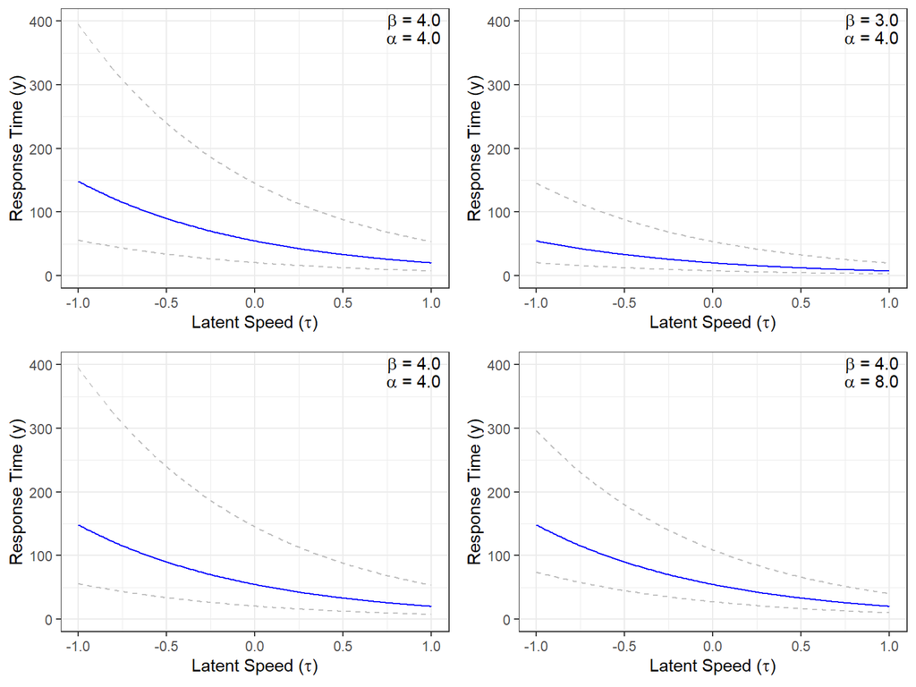

## Let’s make the model a little bit more complex!

We will add a few more parameters to the original LNRT model to detect examinees with item preknowledge and items being compromised simultaneously. These modifications are inspired by the Deterministic Gated IRT model by [Shu et al. (2013)](https://link.springer.com/article/10.1007/s11336-012-9311-3). In an earlier attempt by [Kasli et al. (2020)](https://psyarxiv.com/bqa3t), we applied the idea of Shu et al. (2013) to modeling response times. However, a critical limitation for both Shu et al. (2013) and Kasli et al. (2020) is that they assume the set of compromised items is known, and this information enters into the model as data. In this post, I try to improve it further by relaxing that assumption. Instead of assuming that the compromised status of each item is known, I estimate this as a parameter.

I first hypothesize that there are two latent speed parameters for each examinee, a true latent speed parameter and a cheating latent speed parameter. The model operationalizes the true latent speed when responding to an uncompromised item ($\tau_{ti}$) and the cheating latent speed when responding to a compromised item ($\tau_{ci}$). In addition, we add a discrete person parameter for each examinee ($H_i$) indicating whether an examinee has item preknowledge (0: examinee does not have preknowlegde, 1: examinee has preknowledge) and add a discrete parameter for each item ($C_j$) indicating whether or not an item is compromised.

In this modified model, the log of the response time the $i^{th}$ person on the $j^{th}$ item is assumed to follow a normal distribution

$$\begin{equation}
RT_{ij} | \tau_{ti},\tau_{ci},H_i,\alpha_j,\beta_j,C_j \sim N(\mu_{ij},\sigma_j)
\tag{5}
\end{equation}$$

with a density function

$$\begin{equation}
f(RT_{ij} | \tau_{ti},\tau_{ci},H_i,\alpha_j,\beta_j,C_j) = \frac{1}{\sigma_j \sqrt{2\pi}} e^{-\frac{1}{2}(\frac{RT_{ij} - \mu_{ij}}{\sigma_j})^2}
\tag{6}
\end{equation}$$

where $\mu_{ij}$ and $\sigma_j$ are defined as

$$\begin{equation}
\mu_{ij} = (\beta_j - \tau_{ti})^{1-H_i} \times \Big (C_j \times (\beta_j - \tau_{ci}) + (1-C_j) \times (\beta_j - \tau_{ti} \Big )^{H_i}
\tag{7}
\end{equation}$$

$$\begin{equation}
\sigma_{j} = \frac{1}{\alpha_j}.
\tag{8}
\end{equation}$$

Eq. (7) seems a bit confusing. It just indicates that the expected response time is equal to
$$\beta_j - \tau_{ci},$$

when an examinee has item preknowledge and responds to a compromised item ($H_i=1, C_j=1$), and equal to

$$\beta_j - \tau_{ti},$$

in all other three scenarios,($H_i=1,C_j=0$; $H_i=0,C_j=1$; $H_i=0,C_j=0$).

To implement the model in Stan, we also have to rewrite the original density function to marginalize the discrete parameters. Stan, in its current form, cannot handle discrete parameters in the model. Therefore, we have to explicitly write the original density function for every possible combination of the discrete parameters. Later, we will use the following to model the response time.

$$\begin{aligned}
f(RT_{ij}| \tau_{ti},\tau_{ci},H_i,\alpha_j,b_j,C_j) =
f(RT_{ij}| \tau_{ti},\tau_{ci},\alpha_j,\beta_j,C_j=1,H_i=1) \times P(C_j = 1) \times P(H_i =1) +\\
f(RT_{ij}| \tau_{ti},\tau_{ci},\alpha_j,\beta_j,C_j=1,H_i=0) \times P(C_j = 1) \times P(H_i =0) +\\
f(RT_{ij}| \tau_{ti},\tau_{ci},\alpha_j,\beta_j,C_j=0,H_i=1) \times P(C_j = 0) \times P(H_i =1) +\\
f(RT_{ij}| \tau_{ti},\tau_{ci},\alpha_j,\beta_j,C_j=0,H_i=0) \times P(C_j = 0) \times P(H_i =0)
\end{aligned}$$
Or, we can write it in a less cluttered way.

$$\begin{aligned}
f(RT_{ij}| \tau_{ti},\tau_{ci},H_i,\alpha_j,\beta_j,C_j) =
f(RT_{ij}| \tau_{ci},\alpha_j,\beta_j) \times P(C_j = 1) \times P(H_i =1) +\\
f(RT_{ij}| \tau_{ti},\alpha_j,\beta_j) \times P(C_j = 1) \times P(H_i =0) +\\
f(RT_{ij}| \tau_{ti},\alpha_j,\beta_j) \times P(C_j = 0) \times P(H_i =1) +\\
f(RT_{ij}| \tau_{ti},\alpha_j,\beta_j) \times P(C_j = 0) \times P(H_i =0)
\end{aligned}$$

$P(C_j = 1)$ represents the probability of the jth item being compromised and $P(H_i = 1)$ represents the probability of the ith examinee having item preknowledge. Notice that we consider four possible combinations of the discrete parameters and write the density for each possible combination. While the density relies on $\tau_{ci}$ when ($H_i=1, C_j=1$), it relied on $\tau_{ti}$ for other three possible combinations.

## Model Identification and Prior Specifications

We assume that the joint distribution of true latent speed and cheating latent speed follow a multivariate normal distribution.

$$\begin{pmatrix}
\tau_{t}\\ \tau_{c}
\end{pmatrix}
=
N(\mu_{\mathcal{P}},\Sigma_{\mathcal{P}} )$$

with $\mu_{\mathcal{P}}$ is a vector of means and $\Sigma_{\mathcal{P}}$ is the covariance matrix decomposed into a diagonal matrix of standard deviations and a correlation matrix for person parameters.

$$\Sigma_{\mathcal{P}} =
\begin{pmatrix}
\sigma_{\tau_t} & 0\\
0 & \sigma_{\tau_c}
\end{pmatrix}
\Omega_\mathcal{P}
\begin{pmatrix}
\sigma_{\tau_t} & 0\\
0 & \sigma_{\tau_c}
\end{pmatrix},$$

$$\Omega_\mathcal{P}=
\begin{pmatrix}
1 & \rho_{\tau_t,\tau_c}\\
\rho_{\tau_c,\tau_t} & 1
\end{pmatrix}$$

This decomposition is a recommended practice in [Stan User’s Guide](https://mc-stan.org/docs/2_27/stan-users-guide/multivariate-hierarchical-priors-section.html). For model identification purposes, the mean vector of person parameters are fixed to zero,
$$\mu_{\mathcal{P}} = (0,0).$$
The standard deviations and the correlation matrix are parameters to be estimated with the following priors:

$$\sigma_{\tau_t} \sim exp(1) \\
\sigma_{\tau_c} \sim exp(1) \\
\Omega_{\mathcal{P}} \sim LKJ(1)$$

[Lewandowski-Kurowicka-Joe (LKJ)](https://distribution-explorer.github.io/multivariate_continuous/lkj.html) distribution with a parameter 1 is used as a prior for the correlation matrices as recommended in the [Stan User’s Guide](https://mc-stan.org/docs/2_18/stan-users-guide/multivariate-hierarchical-priors-section.html). For more information about the LKJ distribution, also see [this link](http://srmart.in/is-the-lkj1-prior-uniform-yes/).

The item parameters are similarly assumed to follow a multivariate normal distribution. The only caveat is that I prefer working with the log of the $\alpha$ parameter.

$$\begin{pmatrix}
ln(\alpha) \\ \beta
\end{pmatrix}
=
N(\mu_{\mathcal{I}},\Sigma_{\mathcal{I}} )$$

with $\mu_{\mathcal{I}}$ is a vector of means and $\Sigma_{\mathcal{I}}$ is the covariance matrix decomposed into a diagonal matrix of standard deviations and a correlation matrix for item parameters.

$$\Sigma_{\mathcal{I}} =
\begin{pmatrix}
\sigma_{ln(\alpha)} & 0 \\
0 & \sigma_{\beta}
\end{pmatrix}
\Omega_\mathcal{I}
\begin{pmatrix}
\sigma_{ln(\alpha)} & 0\\
0 & \sigma_{\beta}
\end{pmatrix}$$

$$\Omega_\mathcal{I}=\begin{pmatrix}
1 & \rho_{ln(\alpha),\beta}\\
\rho_{ln(\alpha),\beta} & 1
\end{pmatrix}$$

The following priors can be used for the parameters related to item characteristics.

Finally, we can define the following non-informative priors on the probability that a person is having item preknowledge and the probability that an item is being compromised.

$$P(H_i =1) \sim Beta(1,1) \\
P(C_j =1) \sim Beta(1,1)$$